# Introduction to statistics

Authors

Affiliations

dr.sc. Paula Štancl

Kuzman Consulting d.o.o

dr.sc. Andrea Gelemanović

MedILS, UNIST

# Part 1: Exploratory data analysis

## Define research question

We will investigate another build-in dataset **`mtcars`**.

Let’s say that our research question will be: “Which factors are most associated with fuel efficiency (mpg) in cars?”

We will treat mpg (miles per gallon) as the outcome variable and analyze the effects of other available characteristics on it.

#### Question:

Where can we obtain some information about this dataset?

## Load the data

#### Question:

What is the very first thing you do when starting a new analysis?

```r
# Data manipulation
library(data.table)

# Visualization
library(ggplot2)
library(ggpubr)        # For gghistogram, ggboxplot, ggscatter, stat_compare_means, stat_cor
library(corrplot)      # For correlation matrix plot

# Outlier detection
library(rstatix)       # identify_outliers
library(outliers)      # grubbs.test
library(EnvStats)      # rosnerTest

# Correlation matrix with p-values
library(Hmisc)         # rcorr

# Variance Inflation Factor (VIF) to check multicollinearity
library(car)          # vif
```

```r
dt <- as.data.table(mtcars)
str(dt)
```

```
Classes 'data.table' and 'data.frame':  32 obs. of  11 variables:
 $ mpg : num  21 21 22.8 21.4 18.7 18.1 14.3 24.4 22.8 19.2 ...
 $ cyl : num  6 6 4 6 8 6 8 4 4 6 ...
 $ disp: num  160 160 108 258 360 ...
 $ hp  : num  110 110 93 110 175 105 245 62 95 123 ...
 $ drat: num  3.9 3.9 3.85 3.08 3.15 2.76 3.21 3.69 3.92 3.92 ...
 $ wt  : num  2.62 2.88 2.32 3.21 3.44 ...
 $ qsec: num  16.5 17 18.6 19.4 17 ...
 $ vs  : num  0 0 1 1 0 1 0 1 1 1 ...
 $ am  : num  1 1 1 0 0 0 0 0 0 0 ...
 $ gear: num  4 4 4 3 3 3 3 4 4 4 ...
 $ carb: num  4 4 1 1 2 1 4 2 2 4 ...
 - attr(*, ".internal.selfref")=<externalptr>
```

```r
summary(dt)
```

```
      mpg             cyl             disp             hp
 Min.   :10.40   Min.   :4.000   Min.   : 71.1   Min.   : 52.0
 1st Qu.:15.43   1st Qu.:4.000   1st Qu.:120.8   1st Qu.: 96.5
 Median :19.20   Median :6.000   Median :196.3   Median :123.0
 Mean   :20.09   Mean   :6.188   Mean   :230.7   Mean   :146.7
 3rd Qu.:22.80   3rd Qu.:8.000   3rd Qu.:326.0   3rd Qu.:180.0
 Max.   :33.90   Max.   :8.000   Max.   :472.0   Max.   :335.0
      drat             wt             qsec             vs
 Min.   :2.760   Min.   :1.513   Min.   :14.50   Min.   :0.0000
 1st Qu.:3.080   1st Qu.:2.581   1st Qu.:16.89   1st Qu.:0.0000
 Median :3.695   Median :3.325   Median :17.71   Median :0.0000
 Mean   :3.597   Mean   :3.217   Mean   :17.85   Mean   :0.4375
 3rd Qu.:3.920   3rd Qu.:3.610   3rd Qu.:18.90   3rd Qu.:1.0000
 Max.   :4.930   Max.   :5.424   Max.   :22.90   Max.   :1.0000
       am              gear            carb
 Min.   :0.0000   Min.   :3.000   Min.   :1.000
 1st Qu.:0.0000   1st Qu.:3.000   1st Qu.:2.000
 Median :0.0000   Median :4.000   Median :2.000
 Mean   :0.4062   Mean   :3.688   Mean   :2.812
 3rd Qu.:1.0000   3rd Qu.:4.000   3rd Qu.:4.000
 Max.   :1.0000   Max.   :5.000   Max.   :8.000
```

```r
head(dt)
```

| mpg | cyl | disp | hp | drat | wt | qsec | vs | am | gear | carb |
| --- | --- | --- | --- | --- | --- | --- | --- | --- | --- | --- |
| 21.0 | 6 | 160 | 110 | 3.90 | 2.620 | 16.46 | 0 | 1 | 4 | 4 |
| 21.0 | 6 | 160 | 110 | 3.90 | 2.875 | 17.02 | 0 | 1 | 4 | 4 |
| 22.8 | 4 | 108 | 93 | 3.85 | 2.320 | 18.61 | 1 | 1 | 4 | 1 |
| 21.4 | 6 | 258 | 110 | 3.08 | 3.215 | 19.44 | 1 | 0 | 3 | 1 |
| 18.7 | 8 | 360 | 175 | 3.15 | 3.440 | 17.02 | 0 | 0 | 3 | 2 |
| 18.1 | 6 | 225 | 105 | 2.76 | 3.460 | 20.22 | 1 | 0 | 3 | 1 |

What can you conclude from your data?

- *mpg*: Fuel efficiency (miles per gallon) - dependent variable
- *hp, wt, disp*: Numeric predictors
- *am, cyl, gear*: Categorical factors

### Check categorical variables

```r
lapply(dt[, .(cyl, am, gear)], table)
```

```
$cyl

 4  6  8
11  7 14

$am

 0  1
19 13

$gear

 3  4  5
15 12  5
```

### Convert numerical variables to categorical

We want to do this to ensure that R will treat am, gear, cyl as categorical variables, not continuous numerical. This is crucial because comparing means across groups (e.g. Automatic vs Manual) requires factors, not numbers.

```r
# Apply factor conversion with correct labeling
# 'am' is 0 = Automatic, 1 = Manual
dt[, cyl := as.factor(cyl)]
dt[, gear := as.factor(gear)]
dt[, am := factor(am, levels = c(0, 1), labels = c("Automatic", "Manual"))]
```

**Check categorical variables (again)**

```r
lapply(dt[, .(cyl, am, gear)], table)
```

```
$cyl

 4  6  8
11  7 14

$am

Automatic    Manual
       19        13

$gear

 3  4  5
15 12  5
```

#### Question:

Can you define what type of data is `factor` in R?

#### Task:

Make descriptive statistics for *mpg* variable grouped by 1) *am* and 2) *cyl*.

```r
# Write your solution here
```

## Familiarize yourself with the data

To evaluate some descriptive statistics we can first visually inspect the data.

### Normality check

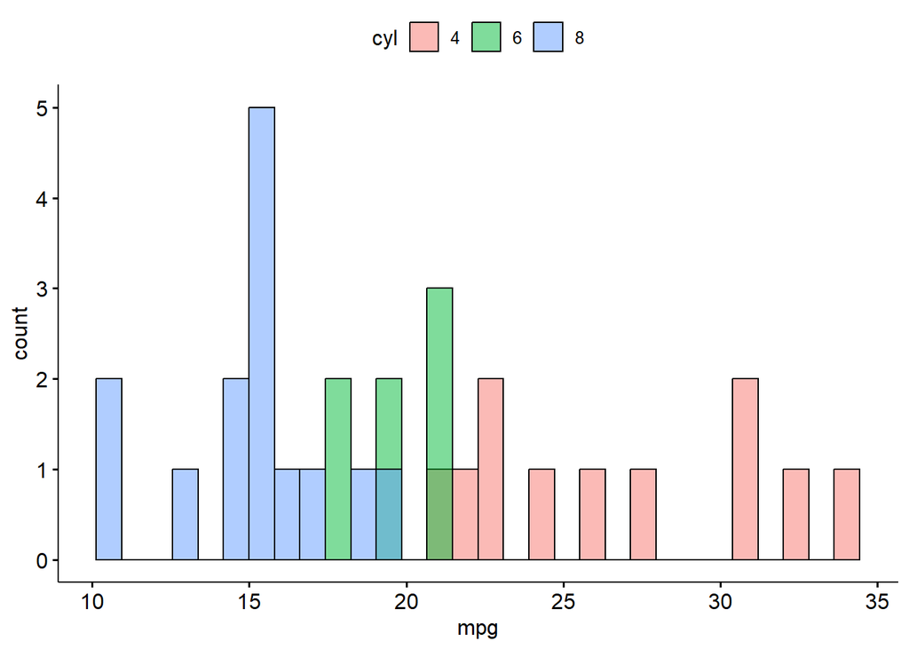

```r
# Make histograms
gghistogram(dt, x = "mpg", fill = "cyl")
```

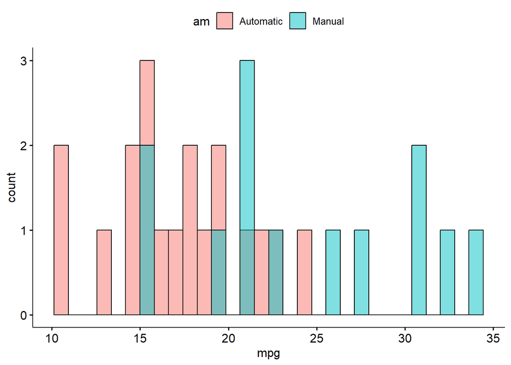

```r
gghistogram(dt, x = "mpg", fill = "am")
```

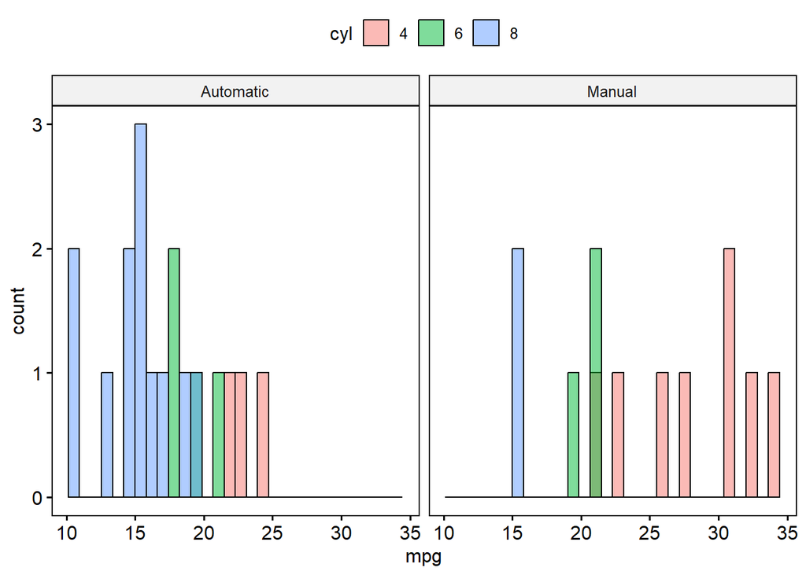

```r
gghistogram(dt, x = "mpg", fill = "cyl", facet.by = "am")
```

#### Question:

What function `ggdensity` does?

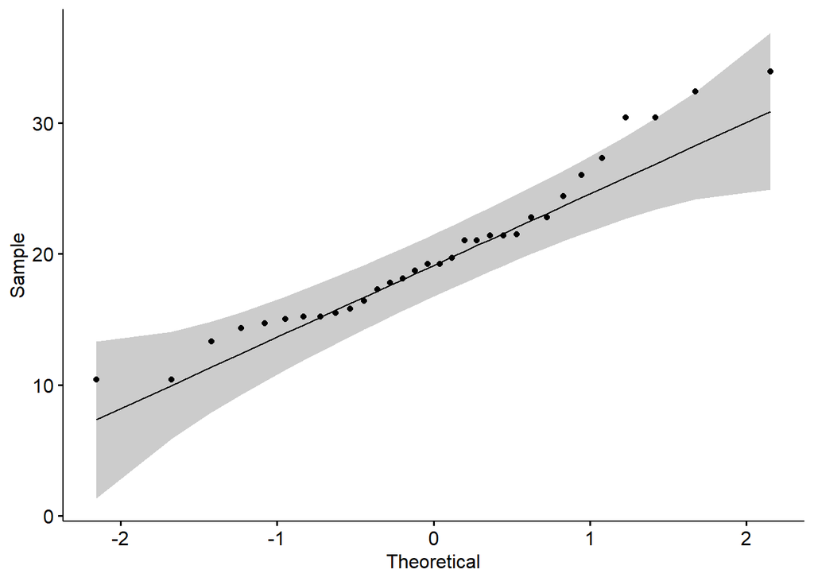

```r
# Make Q-Q plot
ggqqplot(dt, x = "mpg")
```

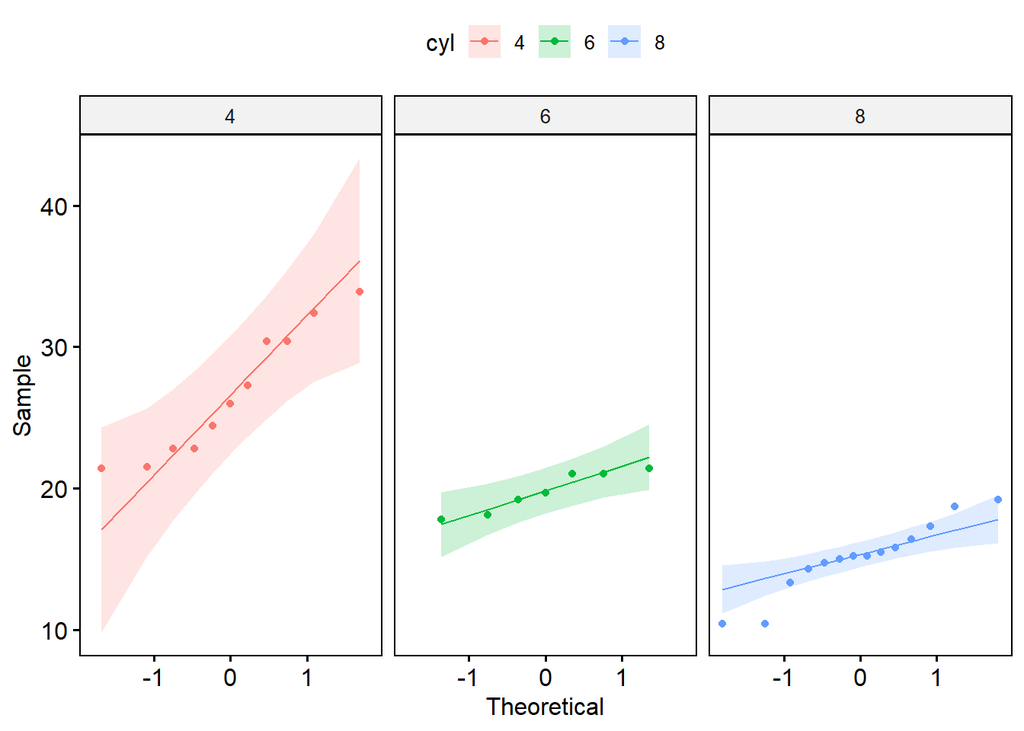

```r
ggqqplot(dt, x = "mpg", color = "cyl", facet.by = "cyl")
```

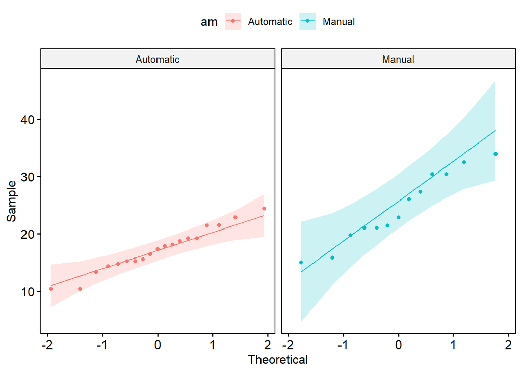

```r
ggqqplot(dt, x = "mpg", color = "am", facet.by = "am")
```

```r
# Run statistical test
shapiro.test(dt$mpg)
```

```
    Shapiro-Wilk normality test

data:  dt$mpg
W = 0.94756, p-value = 0.1229
```

### Boxplot with significance test

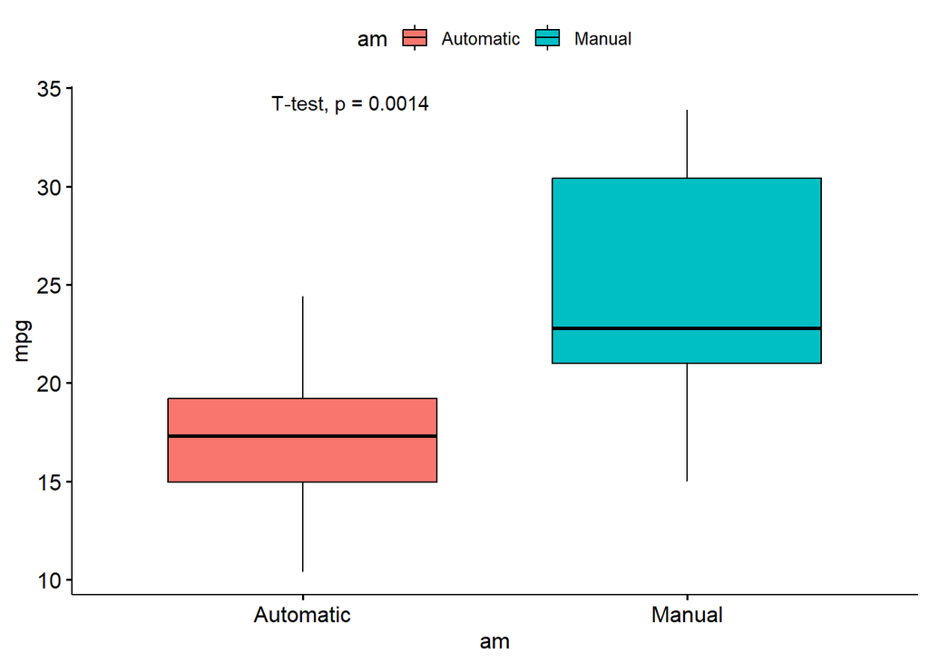

```r
ggboxplot(dt, x = "am", y = "mpg", fill = "am") +
  stat_compare_means(method = "t.test")
```

#### Task:

Can you detect any outliers in other variables?

```r
# Write your solution here
```

### Outlier detection

**Outlier detection using descriptive statistics methods**

Apart from visual inspection with boxplots, outliers can also be detected via several descriptive statistics (including minimum, maximum, histogram, and percentiles) or thanks to more formal techniques of outliers detection using statistical tests. Once you detect a possible outlier, it is up to you to decide how to treat them (i.e., keeping, removing or imputing them) before conducting further analyses.

**Outlier detection using descriptive statistics methods**

```r
# SD method - those that are 2 x SD away from mean
mean_mpg <- mean(dt$mpg)
sd_mpg <- sd(dt$mpg)
dt[mpg < mean_mpg - 2 * sd_mpg | mpg > mean_mpg + 2 * sd_mpg]
```

| mpg | cyl | disp | hp | drat | wt | qsec | vs | am | gear | carb |
| --- | --- | --- | --- | --- | --- | --- | --- | --- | --- | --- |
| 32.4 | 4 | 78.7 | 66 | 4.08 | 2.200 | 19.47 | 1 | Manual | 4 | 1 |
| 33.9 | 4 | 71.1 | 65 | 4.22 | 1.835 | 19.90 | 1 | Manual | 4 | 1 |

```r
# IQR method - those that are 1.5 x IQR away from 1st or 3rd quartile
identify_outliers(data = dt, variable = "mpg")
```

| mpg | cyl | disp | hp | drat | wt | qsec | vs | am | gear | carb | is.outlier | is.extreme |
| --- | --- | --- | --- | --- | --- | --- | --- | --- | --- | --- | --- | --- |
| 33.9 | 4 | 71.1 | 65 | 4.22 | 1.835 | 19.9 | 1 | Manual | 4 | 1 | TRUE | FALSE |

```r
# Z-score method (if your data has a normal distribution)
# A z-score below -3.29 or above 3.29 means you have detected outliers.
# This value of 3.29 comes from the fact that 1 observation out of 1000 is out of this interval if the data follow a normal distribution.
z_scores <- scale(dt$mpg)
dt[, z_mpg := z_scores]
dt[abs(z_mpg) > 3.29]
```

| mpg | cyl | disp | hp | drat | wt | qsec | vs | am | gear | carb | z_mpg |
| --- | --- | --- | --- | --- | --- | --- | --- | --- | --- | --- | --- |

#### Question:

Can you conclude what `scale` does?

### Outlier detection using statistical tests

Take into consideration that these tests assume normality of the data.

*The Grubbs test*

It allows to detect whether the highest or lowest value in a dataset is an outlier. It only detects one outlier at a time. It is not appropriate for sample size of 6 or less.

```r
grubbs.test(dt$mpg)
```

```
    Grubbs test for one outlier

data:  dt$mpg
G = 2.29127, U = 0.82518, p-value = 0.276
alternative hypothesis: highest value 33.9 is an outlier
```

```r
grubbs.test(dt$mpg, opposite = TRUE)
```

```
    Grubbs test for one outlier

data:  dt$mpg
G = 1.60788, U = 0.91391, p-value = 1
alternative hypothesis: lowest value 10.4 is an outlier
```

*Dixon test*

Similar to the Grubbs test, Dixon test is used to test whether a single low or high value is an outlier. So if more than one outliers is suspected, the test has to be performed on these suspected outliers individually. This test is most useful for small sample size (usually n ≤ 25).

```r
dixon.test(dt$mpg)
```

```
Error in dixon.test(dt$mpg): Sample size must be in range 3-30
```

It is a good practice to always check the results of the statistical test for outliers against the boxplot to make sure we tested all potential outliers.

If outlier is detected, find and exclude highest value (i.e. outlier) and then repeat the Dixon test on dataset without this outlier.

*Rosner test*

It is used to detect several outliers at once (unlike Grubbs and Dixon test which must be performed iteratively to screen for multiple outliers), and it is designed to avoid the problem of masking, where an outlier that is close in value to another outlier can go undetected. It is most appropriate when the sample size is large (n ≥ 20).

```r
rosnerTest(dt$mpg, k = 1)
```

```
$distribution
[1] "Normal"

$statistic
     R.1
2.291272

$sample.size
[1] 32

$parameters
k
1

$alpha
[1] 0.05

$crit.value
lambda.1
2.938048

$n.outliers
[1] 0

$alternative
[1] "Up to 1 observations are not\n                                 from the same Distribution."

$method
[1] "Rosner's Test for Outliers"

$data
 [1] 21.0 21.0 22.8 21.4 18.7 18.1 14.3 24.4 22.8 19.2 17.8 16.4 17.3 15.2 10.4
[16] 10.4 14.7 32.4 30.4 33.9 21.5 15.5 15.2 13.3 19.2 27.3 26.0 30.4 15.8 19.7
[31] 15.0 21.4

$data.name
[1] "dt$mpg"

$bad.obs
[1] 0

$all.stats
  i   Mean.i     SD.i Value Obs.Num    R.i+1 lambda.i+1 Outlier
1 0 20.09062 6.026948  33.9      20 2.291272   2.938048   FALSE

attr(,"class")
[1] "gofOutlier"
```

### Checking for correlation patterns

We can first visually inspect correlations by creating scatter plots:

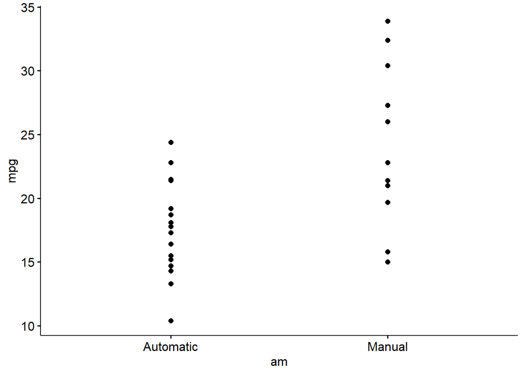

```r
ggscatter(data = dt,
          x = "am",
          y = "mpg",
          add = "reg.line")
```

What if you want to do correlation analysis for all available numeric variables?

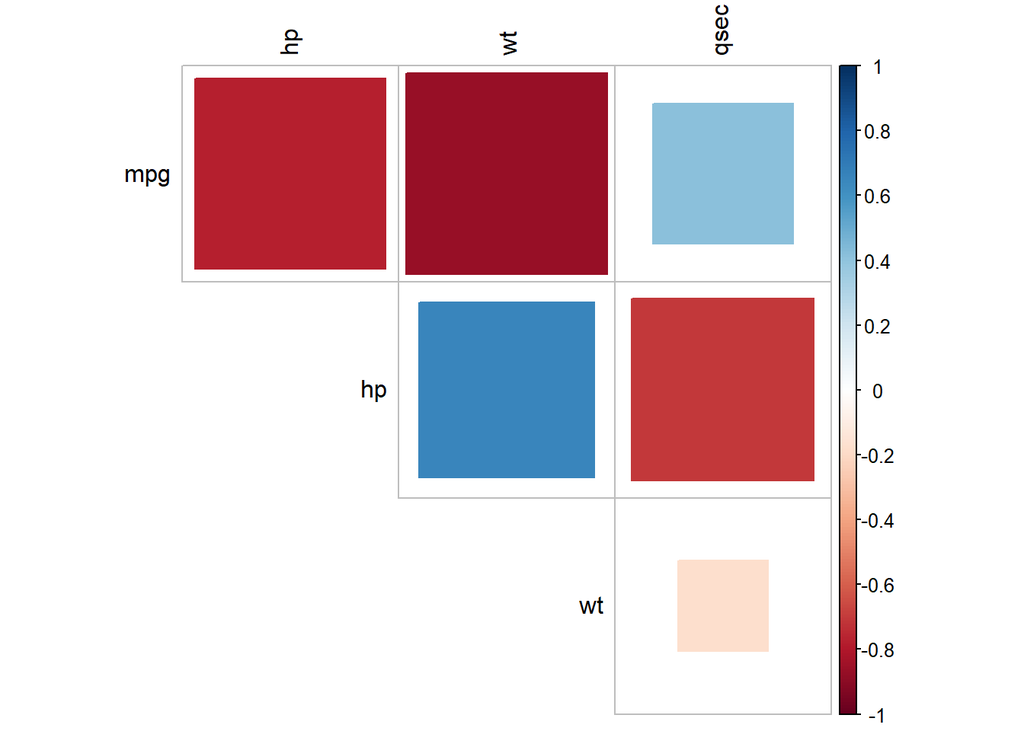

```r
cor_data <- dt[, .(mpg, hp, wt, qsec)]
cor_matrix <- cor(cor_data)
corrplot(cor_matrix, method = 'square', type = 'upper', diag = FALSE, tl.col = "black")
```

**Correlation ≠ Collinearity**

Correlation shows **linear association between two variables only**.

**Multicollinearity** can involve **more than two variables**, and this isn’t captured by correlation alone.

Two variables can have **low pairwise correlation**, but still cause multicollinearity **in combination with others**.

# PART 2: Statistical analysis

### Categorical data analysis: Chi-square Test

To investigate if there is any statistical difference between the groups we use chi-square test for categorical data.

```r
chisq.test(table(dt$am, dt$cyl))
```

```
    Pearson's Chi-squared test

data:  table(dt$am, dt$cyl)
X-squared = 8.7407, df = 2, p-value = 0.01265
```

#### Question:

How can we make some visual representation of this categorical data? For homework :)

### Numerical data analysis

First, we need to evaluate if there is a normal distribution with our numerical data (Shapiro-Wilk test or Kolmogorov-Smirnov test).

If the data is normally distributed, we can investigate if there is statistical difference between groups using T-test (if we compare two groups) or ANOVA (if we compare more than two groups).

If the data is not normally distributed, we can investigate if there is statistical difference between groups using Mann-Whitney U test (if we compare two groups) or Kruskal-Wallis test (if we compare more than two groups).

If you are working with paired data (same individuals measured more than once, e.g. before or after the treatment, several different time points), we need to use paired versions of all the above mentioned tests (usually by adding parameter “paired = TRUE” in your statistical test functions).

#### Task:

Perform statistical test to check data normality and visualize it.

```r
# Write your solution here
```

Let’s run some statistical tests - two groups comparison:

```r
t.test(mpg ~ am, data = dt)
```

```
    Welch Two Sample t-test

data:  mpg by am
t = -3.7671, df = 18.332, p-value = 0.001374
alternative hypothesis: true difference in means between group Automatic and group Manual is not equal to 0
95 percent confidence interval:
 -11.280194  -3.209684
sample estimates:
mean in group Automatic    mean in group Manual
               17.14737                24.39231
```

**Important**

By default, `t.test()` uses **Welch’s t-test**, which **does not assume equal variances** between the two groups.

If you want to perform the **Student’s t-test** (i.e. assuming equal variances), you need to explicitly set the argument `var.equal = TRUE`.

**Variance is a measure of how spread out the values are in a dataset**. Two groups can have the same mean but very different spreads (variances).

How to check equal variance? Use F-test:

var.test(mpg ~ am, data = dt)

- **p < 0.05** Variances are significantly different (don’t assume equal variances)
- **p ≥ 0.05** No strong evidence of difference (safe to assume equal variances)

```r
t.test(mpg ~ am, data = dt, var.equal = TRUE)
```

```
    Two Sample t-test

data:  mpg by am
t = -4.1061, df = 30, p-value = 0.000285
alternative hypothesis: true difference in means between group Automatic and group Manual is not equal to 0
95 percent confidence interval:
 -10.84837  -3.64151
sample estimates:
mean in group Automatic    mean in group Manual
               17.14737                24.39231
```

```r
wilcox.test(mpg ~ am, data = dt)
```

```
    Wilcoxon rank sum test with continuity correction

data:  mpg by am
W = 42, p-value = 0.001871
alternative hypothesis: true location shift is not equal to 0
```

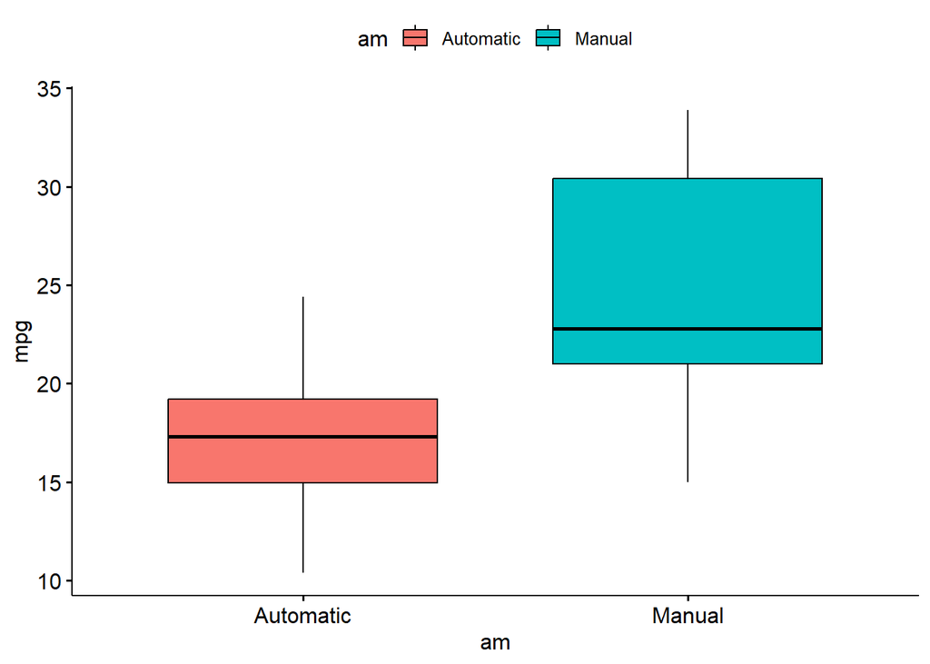

```r
ggboxplot(dt, x = "am", y = "mpg", fill = "am")
```

And now for some 2+ groups:

```r
summary(aov(mpg ~ gear, data = dt))
```

```
            Df Sum Sq Mean Sq F value   Pr(>F)
gear         2  483.2  241.62    10.9 0.000295 ***
Residuals   29  642.8   22.17
---
Signif. codes:  0 '***' 0.001 '**' 0.01 '*' 0.05 '.' 0.1 ' ' 1
```

```r
kruskal.test(mpg ~ gear, data = dt)
```

```
    Kruskal-Wallis rank sum test

data:  mpg by gear
Kruskal-Wallis chi-squared = 14.323, df = 2, p-value = 0.0007758
```

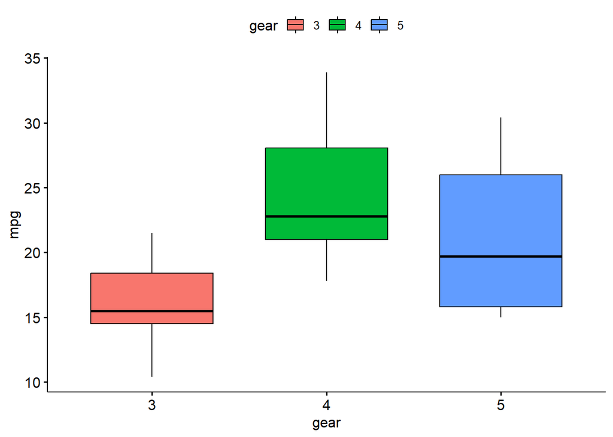

```r
ggboxplot(dt, x = "gear", y = "mpg", fill = "gear")
```

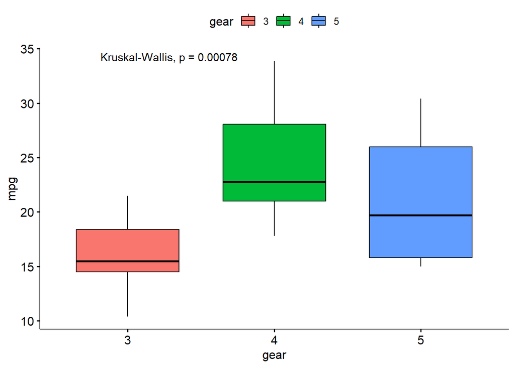

```r
ggboxplot(dt, x = "gear", y = "mpg", fill = "gear") +
  stat_compare_means()
```

#### Question:

What is mandatory next step after anova?

```r
TukeyHSD(aov(mpg ~ gear, data = dt))
```

```
  Tukey multiple comparisons of means
    95% family-wise confidence level

Fit: aov(formula = mpg ~ gear, data = dt)

$gear
         diff        lwr       upr     p adj
4-3  8.426667  3.9234704 12.929863 0.0002088
5-3  5.273333 -0.7309284 11.277595 0.0937176
5-4 -3.153333 -9.3423846  3.035718 0.4295874
```

### Correlation analysis

We can run correlations to assess how two variables are associated with one another. There is no direction here. Coefficient of correlation can go from -1 (very negative correlation) to 1 (very positive correlation).

#### Task:

We learned how to do basic correlation analysis, but if we want to check correlations between all numerical variables & get the statistical significance, we can use function rcorr from package Hmisc. Try it out!

```r
# Write your solution here
```

#### Task:

How can we improve our `corrplot` to add statistical significance?

```r
# Write your solution here
```

### Regression models

We use linear regression models when our dependent variable is numerical, and logistic regression models when we have binary categorical dependent variable.

```r
# Logistic regression
dt[, am_binary := ifelse(am == "Manual", 1, 0)]

model1 <- glm(am_binary ~ hp, data = dt, family = "binomial")
summary(model1)
```

```
Call:
glm(formula = am_binary ~ hp, family = "binomial", data = dt)

Coefficients:
             Estimate Std. Error z value Pr(>|z|)
(Intercept)  0.776614   0.915429   0.848    0.396
hp          -0.008117   0.006074  -1.336    0.181

(Dispersion parameter for binomial family taken to be 1)

    Null deviance: 43.230  on 31  degrees of freedom
Residual deviance: 41.228  on 30  degrees of freedom
AIC: 45.228

Number of Fisher Scoring iterations: 4
```

**Important**

If we **did not manually create a binary variable** `am_binary`, and we used the factor `am` (e.g. `Automatic`/`Manual`) in the regression model, R will **automatically choose a reference level** based on the **alphabetical order** of the factor levels **unless you specify otherwise**. The first level alphabetically becomes the **reference category** and is coded as `0`, and the other as `1`.

```r
# Linear regression
model2 <- lm(mpg ~ hp, data = dt)
summary(model2)
```

```
Call:
lm(formula = mpg ~ hp, data = dt)

Residuals:
    Min      1Q  Median      3Q     Max
-5.7121 -2.1122 -0.8854  1.5819  8.2360

Coefficients:
            Estimate Std. Error t value Pr(>|t|)
(Intercept) 30.09886    1.63392  18.421  < 2e-16 ***
hp          -0.06823    0.01012  -6.742 1.79e-07 ***
---
Signif. codes:  0 '***' 0.001 '**' 0.01 '*' 0.05 '.' 0.1 ' ' 1

Residual standard error: 3.863 on 30 degrees of freedom
Multiple R-squared:  0.6024,    Adjusted R-squared:  0.5892
F-statistic: 45.46 on 1 and 30 DF,  p-value: 1.788e-07
```

#### Task:

Perform now a multivariate regressions:

```r
# Write your solution here
```

To properly assess multicollinearity, we need to check the Variance Inflation Factor (VIF) which is a proper diagnostic tool.

```r
# Multivariable linear regression
model_multi <- lm(mpg ~ hp + wt + qsec, data = dt)
summary(model_multi)
```

```
Call:
lm(formula = mpg ~ hp + wt + qsec, data = dt)

Residuals:
    Min      1Q  Median      3Q     Max
-3.8591 -1.6418 -0.4636  1.1940  5.6092

Coefficients:
            Estimate Std. Error t value Pr(>|t|)
(Intercept) 27.61053    8.41993   3.279  0.00278 **
hp          -0.01782    0.01498  -1.190  0.24418
wt          -4.35880    0.75270  -5.791 3.22e-06 ***
qsec         0.51083    0.43922   1.163  0.25463
---
Signif. codes:  0 '***' 0.001 '**' 0.01 '*' 0.05 '.' 0.1 ' ' 1

Residual standard error: 2.578 on 28 degrees of freedom
Multiple R-squared:  0.8348,    Adjusted R-squared:  0.8171
F-statistic: 47.15 on 3 and 28 DF,  p-value: 4.506e-11
```

```r
# Calculate VIF
vif(model_multi)
```

```
      hp       wt     qsec
4.921956 2.530443 2.873804
```

What is the interpretation?

- `hp` is moderately correlated with the other variables in our model.

**VIF ≈ 1**: No multicollinearity

**VIF > 5**: Moderate multicollinearity (can be a concern)

**VIF > 10**: High multicollinearity (serious concern)